# Exploratory Data Analysis

## I. Vegas Hotel Dataset:

**1. Reading Vegas hotel data from csv file and viewing the structure of the dataset:**

```r
vegashotels = read.csv2("vegashotels-1.csv", stringsAsFactors = TRUE)
str(vegashotels)
```

```
'data.frame':   504 obs. of  20 variables:
 $ User.country     : Factor w/ 48 levels "Australia","Belgium",..: 48 48 48 46 4 4 46 48 18 4 ...
 $ Nr..reviews      : int  11 119 36 14 5 31 45 2 24 12 ...
 $ Nr..hotel.reviews: int  4 21 9 7 5 8 12 1 3 7 ...
 $ Helpful.votes    : int  13 75 25 14 2 27 46 4 8 11 ...
 $ Score            : int  5 3 5 4 4 3 4 4 4 3 ...
 $ Period.of.stay   : Factor w/ 4 levels "Dec-Feb","Jun-Aug",..: 1 1 3 3 3 3 3 3 3 3 ...
 $ Traveler.type    : Factor w/ 5 levels "Business","Couples",..: 4 1 3 4 5 2 2 3 4 3 ...
 $ Pool             : Factor w/ 2 levels "NO","YES": 1 1 1 1 1 1 1 1 1 1 ...
 $ Gym              : Factor w/ 2 levels "NO","YES": 2 2 2 2 2 2 2 2 2 2 ...
 $ Tennis.court     : Factor w/ 2 levels "NO","YES": 1 1 1 1 1 1 1 1 1 1 ...
 $ Spa              : Factor w/ 2 levels "NO","YES": 1 1 1 1 1 1 1 1 1 1 ...
 $ Casino           : Factor w/ 2 levels "NO","YES": 2 2 2 2 2 2 2 2 2 2 ...
 $ Free.internet    : Factor w/ 2 levels "NO","YES": 2 2 2 2 2 2 2 2 2 2 ...
 $ Hotel.name       : Factor w/ 21 levels "Bellagio Las Vegas",..: 3 3 3 3 3 3 3 3 3 3 ...
 $ Hotel.stars      : num  3 3 3 3 3 3 3 3 3 3 ...
 $ Nr..rooms        : int  3773 3773 3773 3773 3773 3773 3773 3773 3773 3773 ...
 $ User.continent   : Factor w/ 6 levels "Africa","Asia",..: 4 4 4 3 4 4 3 4 2 4 ...
 $ Member.years     : int  9 3 2 6 7 2 4 0 3 5 ...
 $ Review.month     : Factor w/ 12 levels "April","August",..: 5 5 4 4 8 8 1 1 9 9 ...
 $ Review.weekday   : Factor w/ 7 levels "Friday","Monday",..: 5 1 3 1 6 6 1 6 3 6 ...
```

From the structure of the dataset below are the categorical and numerical attributes:

- Categorical features:
  - User.country, Score, Period.of.stay, Traveler.type, Pool, Gym, Tennis.court, Spa, Casino, Free.internet, Hotel.name, Hotel.stars, User.continent, Review.month, and Review.weekday (total of 15 categorical attributes)
- Numerical features:
  - Nr..reviews, Nr..hotel.reviews, Helpful.votes, Nr..rooms,and Member.years (total of 5 numerical attributes)

2.  
i. Summary statistics of the dataset:

```r
  vegashotels_summary <- summary(vegashotels)
  vegashotels_summary
```

```
    User.country  Nr..reviews     Nr..hotel.reviews Helpful.votes
 USA      :217   Min.   :  1.00   Min.   :  0.00    Min.   :  0.00
 UK       : 72   1st Qu.: 12.00   1st Qu.:  5.00    1st Qu.:  8.00
 Canada   : 65   Median : 23.50   Median :  9.00    Median : 16.00
 Australia: 36   Mean   : 48.13   Mean   : 16.02    Mean   : 31.75
 Ireland  : 13   3rd Qu.: 54.25   3rd Qu.: 18.00    3rd Qu.: 35.00
 India    : 11   Max.   :775.00   Max.   :263.00    Max.   :365.00
 (Other)  : 90
     Score       Period.of.stay  Traveler.type  Pool      Gym      Tennis.court
 Min.   :1.000   Dec-Feb:124    Business: 74   NO : 24   NO : 24   NO :384
 1st Qu.:4.000   Jun-Aug:126    Couples :214   YES:480   YES:480   YES:120
 Median :4.000   Mar-May:128    Families:110
 Mean   :4.123   Sep-Nov:126    Friends : 82
 3rd Qu.:5.000                  Solo    : 24
 Max.   :5.000

  Spa      Casino    Free.internet                                  Hotel.name
 NO :120   NO : 48   NO : 24       Bellagio Las Vegas                    : 24
 YES:384   YES:456   YES:480       Caesars Palace                        : 24
                                   Circus Circus Hotel & Casino Las Vegas: 24
                                   Encore at wynn Las Vegas              : 24
                                   Excalibur Hotel & Casino              : 24
                                   Hilton Grand Vacations at the Flamingo: 24
                                   (Other)                               :360
  Hotel.stars      Nr..rooms          User.continent  Member.years
 Min.   :3.000   Min.   : 188   Africa       :  7    Min.   :-1806.0000
 1st Qu.:3.500   1st Qu.: 826   Asia         : 36    1st Qu.:    2.0000
 Median :4.000   Median :2700   Europe       :118    Median :    4.0000
 Mean   :4.143   Mean   :2196   North America:295    Mean   :    0.7679
 3rd Qu.:5.000   3rd Qu.:3025   Oceania      : 41    3rd Qu.:    6.0000
 Max.   :5.000   Max.   :4027   South America:  7    Max.   :   13.0000

   Review.month   Review.weekday
 April   : 42   Friday   :65
 August  : 42   Monday   :74
 December: 42   Saturday :61
 February: 42   Sunday   :77
 January : 42   Thursday :62
 July    : 42   Tuesday  :80
 (Other) :252   Wednesday:85
```

**ii. Missing values in the variables:**

```r
colSums(is.na(vegashotels))
```

```
     User.country       Nr..reviews Nr..hotel.reviews     Helpful.votes
                0                 0                 0                 0
            Score    Period.of.stay     Traveler.type              Pool
                0                 0                 0                 0
              Gym      Tennis.court               Spa            Casino
                0                 0                 0                 0
    Free.internet        Hotel.name       Hotel.stars         Nr..rooms
                0                 0                 0                 0
   User.continent      Member.years      Review.month    Review.weekday
                0                 0                 0                 0
```

- There are no missing values in the dataset

**3. Histogram of score variable:**

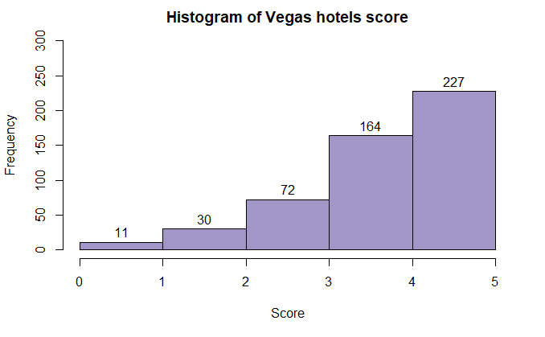

```r
hist(Score, main = "Histogram of Vegas hotels score", xlab = "Score", col = "#A196C5", labels = TRUE, breaks = c(0,1,2,3,4,5), ylim = c(0,300))
```

- From the histogram we can say that 227 of the 504 vegas hotels have a score of 5 which is about 45% of them. And a total of 391 hotels out of 504 hotels have a score of either 4 or 5 which is around 77.5% of the vegas hotels.

**4. Mode of score variable:**

```r
score_table = table(Score)
score_mode = as.numeric(names(score_table))[score_table == max(score_table)]
score_mode
```

```
[1] 5
```

- Mode of the Score variable is 5 meaning a score of 5 is more common than other scores for Vegas hotels.

**5. Quantile and median for Score:**

```r
quantile(Score)
```

```
  0%  25%  50%  75% 100%
   1    4    4    5    5
```

- Median of the Score variable using quantile function is 4

```r
median(Score)
```

```
[1] 4
```

**6. sentiment factor variable that takes the value “positive” if score is 4 or 5 and “negative” otherwise:**

```r
sentiment = factor(ifelse(Score==4 | Score == 5,"positive","negative"))
sentiment
```

```
  [1] positive negative positive positive positive negative positive positive
  [9] positive negative negative negative negative negative negative positive
 [17] negative positive negative negative positive negative positive negative
 [25] positive positive positive negative positive positive positive negative
 [33] negative negative positive negative positive positive positive negative
 [41] negative negative negative positive positive positive positive negative
 [49] negative positive negative positive negative positive positive negative
 [57] positive positive positive positive positive negative negative negative
 [65] negative positive negative negative positive negative negative positive
 [73] negative positive positive positive positive positive positive negative
 [81] negative positive negative positive positive positive positive positive
 [89] negative positive positive negative positive positive positive positive
 [97] positive positive negative negative positive positive positive positive
[105] positive negative positive positive positive positive positive positive
[113] negative positive positive negative positive positive positive positive
```

[output cut: 49 more lines]

**7. Frequency of sentiment and Score variables**

```r
summary(sentiment)
```

```
negative positive
     113      391
```

```r
negative_freq = table(Score)[[1]] + table(Score)[[2]] + table(Score)[[3]]
negative_freq
```

```
[1] 113
```

```r
positive_freq = table(Score)[[4]] + table(Score)[[5]]
positive_freq
```

```
[1] 391
```

- Frequency for the “positive” sentiment is equal to the combined frequency of 4 and 5 for the Score and frequency for the “negative” sentiment is equal to the combined frequency of the rest of the values the Score.

**8. statistical test to determine if sentiment is associated with any of the variables: “Pool”, “Gym”,“Free.Internet”, “Period.of.Stay”, “traverler.type”“, and”hotel.stars" with alpha=0.01**

**i. sentiment vs Pool:**

```r
CrossTable(sentiment,Pool, chisq=TRUE)
```

```
   Cell Contents
|-------------------------|
|                       N |
| Chi-square contribution |
|           N / Row Total |
|           N / Col Total |
|         N / Table Total |
|-------------------------|


Total Observations in Table:  504


             | Pool
   sentiment |        NO |       YES | Row Total |
-------------|-----------|-----------|-----------|
    negative |        13 |       100 |       113 |
             |    10.788 |     0.539 |           |
             |     0.115 |     0.885 |     0.224 |
             |     0.542 |     0.208 |           |
             |     0.026 |     0.198 |           |
-------------|-----------|-----------|-----------|
    positive |        11 |       380 |       391 |
             |     3.118 |     0.156 |           |
             |     0.028 |     0.972 |     0.776 |
             |     0.458 |     0.792 |           |
             |     0.022 |     0.754 |           |
-------------|-----------|-----------|-----------|
Column Total |        24 |       480 |       504 |
             |     0.048 |     0.952 |           |
-------------|-----------|-----------|-----------|


Statistics for All Table Factors


Pearson's Chi-squared test
------------------------------------------------------------
Chi^2 =  14.60109     d.f. =  1     p =  0.0001328376

Pearson's Chi-squared test with Yates' continuity correction
------------------------------------------------------------
Chi^2 =  12.74758     d.f. =  1     p =  0.0003564702
```

- As p value is less than alpha, it can be concluded that there is an association between Pool and sentiment.

**ii. sentiment vs Gym:**

```r
CrossTable(sentiment,Gym, chisq=TRUE)
```

```
   Cell Contents
|-------------------------|
|                       N |
| Chi-square contribution |
|           N / Row Total |
|           N / Col Total |
|         N / Table Total |
|-------------------------|


Total Observations in Table:  504


             | Gym
   sentiment |        NO |       YES | Row Total |
-------------|-----------|-----------|-----------|
    negative |         6 |       107 |       113 |
             |     0.071 |     0.004 |           |
             |     0.053 |     0.947 |     0.224 |
             |     0.250 |     0.223 |           |
             |     0.012 |     0.212 |           |
-------------|-----------|-----------|-----------|
    positive |        18 |       373 |       391 |
             |     0.021 |     0.001 |           |
             |     0.046 |     0.954 |     0.776 |
             |     0.750 |     0.777 |           |
             |     0.036 |     0.740 |           |
-------------|-----------|-----------|-----------|
Column Total |        24 |       480 |       504 |
             |     0.048 |     0.952 |           |
-------------|-----------|-----------|-----------|


Statistics for All Table Factors


Pearson's Chi-squared test
------------------------------------------------------------
Chi^2 =  0.09639001     d.f. =  1     p =  0.7562055

Pearson's Chi-squared test with Yates' continuity correction
------------------------------------------------------------
Chi^2 =  0.003564719     d.f. =  1     p =  0.9523904
```

- As p value is greater than alpha, it can be concluded that there is an NO association between Gym and sentiment.

**iii. sentiment vs Free.internet:**

```r
CrossTable(sentiment,Free.internet, chisq=TRUE)
```

```
   Cell Contents
|-------------------------|
|                       N |
| Chi-square contribution |
|           N / Row Total |
|           N / Col Total |
|         N / Table Total |
|-------------------------|


Total Observations in Table:  504


             | Free.internet
   sentiment |        NO |       YES | Row Total |
-------------|-----------|-----------|-----------|
    negative |        12 |       101 |       113 |
             |     8.142 |     0.407 |           |
             |     0.106 |     0.894 |     0.224 |
             |     0.500 |     0.210 |           |
             |     0.024 |     0.200 |           |
-------------|-----------|-----------|-----------|
    positive |        12 |       379 |       391 |
             |     2.353 |     0.118 |           |
             |     0.031 |     0.969 |     0.776 |
             |     0.500 |     0.790 |           |
             |     0.024 |     0.752 |           |
-------------|-----------|-----------|-----------|
Column Total |        24 |       480 |       504 |
             |     0.048 |     0.952 |           |
-------------|-----------|-----------|-----------|


Statistics for All Table Factors


Pearson's Chi-squared test
------------------------------------------------------------
Chi^2 =  11.01983     d.f. =  1     p =  0.0009014228

Pearson's Chi-squared test with Yates' continuity correction
------------------------------------------------------------
Chi^2 =  9.417846     d.f. =  1     p =  0.002148838
```

- As p value is less than alpha, it can be concluded that there is an association between Free.internet and sentiment.

**iv. sentiment vs Period.of.stay:**

```r
CrossTable(sentiment,Period.of.stay, chisq=TRUE)
```

```
   Cell Contents
|-------------------------|
|                       N |
| Chi-square contribution |
|           N / Row Total |
|           N / Col Total |
|         N / Table Total |
|-------------------------|


Total Observations in Table:  504


             | Period.of.stay
   sentiment |   Dec-Feb |   Jun-Aug |   Mar-May |   Sep-Nov | Row Total |
-------------|-----------|-----------|-----------|-----------|-----------|
    negative |        24 |        24 |        33 |        32 |       113 |
             |     0.520 |     0.639 |     0.645 |     0.498 |           |
             |     0.212 |     0.212 |     0.292 |     0.283 |     0.224 |
             |     0.194 |     0.190 |     0.258 |     0.254 |           |
             |     0.048 |     0.048 |     0.065 |     0.063 |           |
-------------|-----------|-----------|-----------|-----------|-----------|
    positive |       100 |       102 |        95 |        94 |       391 |
             |     0.150 |     0.185 |     0.186 |     0.144 |           |
             |     0.256 |     0.261 |     0.243 |     0.240 |     0.776 |
             |     0.806 |     0.810 |     0.742 |     0.746 |           |
             |     0.198 |     0.202 |     0.188 |     0.187 |           |
-------------|-----------|-----------|-----------|-----------|-----------|
Column Total |       124 |       126 |       128 |       126 |       504 |
             |     0.246 |     0.250 |     0.254 |     0.250 |           |
-------------|-----------|-----------|-----------|-----------|-----------|


Statistics for All Table Factors


Pearson's Chi-squared test
------------------------------------------------------------
Chi^2 =  2.966974     d.f. =  3     p =  0.3967453
```

- As p value is greater than alpha, it can be concluded that there is an NO association between Period.of.stay and sentiment.

**v. sentiment vs Traveler.type:**

```r
CrossTable(sentiment,Traveler.type, chisq=TRUE)
```

```
   Cell Contents
|-------------------------|
|                       N |
| Chi-square contribution |
|           N / Row Total |
|           N / Col Total |
|         N / Table Total |
|-------------------------|


Total Observations in Table:  504


             | Traveler.type
   sentiment |  Business |   Couples |  Families |   Friends |      Solo | Row Total |
-------------|-----------|-----------|-----------|-----------|-----------|-----------|
    negative |        21 |        39 |        33 |        14 |         6 |       113 |
             |     1.172 |     1.681 |     2.818 |     1.046 |     0.071 |           |
             |     0.186 |     0.345 |     0.292 |     0.124 |     0.053 |     0.224 |
             |     0.284 |     0.182 |     0.300 |     0.171 |     0.250 |           |
             |     0.042 |     0.077 |     0.065 |     0.028 |     0.012 |           |
-------------|-----------|-----------|-----------|-----------|-----------|-----------|
    positive |        53 |       175 |        77 |        68 |        18 |       391 |
             |     0.339 |     0.486 |     0.815 |     0.302 |     0.021 |           |
             |     0.136 |     0.448 |     0.197 |     0.174 |     0.046 |     0.776 |
             |     0.716 |     0.818 |     0.700 |     0.829 |     0.750 |           |
             |     0.105 |     0.347 |     0.153 |     0.135 |     0.036 |           |
-------------|-----------|-----------|-----------|-----------|-----------|-----------|
Column Total |        74 |       214 |       110 |        82 |        24 |       504 |
             |     0.147 |     0.425 |     0.218 |     0.163 |     0.048 |           |
-------------|-----------|-----------|-----------|-----------|-----------|-----------|


Statistics for All Table Factors


Pearson's Chi-squared test
------------------------------------------------------------
Chi^2 =  8.749461     d.f. =  4     p =  0.06767611
```

- As p value is greater than alpha, it can be concluded that there is an NO association between Traveler.type and sentiment.

**vi. sentiment vs Hotel.stars:**

```r
CrossTable(sentiment,Hotel.stars, chisq=TRUE)
```

```
   Cell Contents
|-------------------------|
|                       N |
| Chi-square contribution |
|           N / Row Total |
|           N / Col Total |
|         N / Table Total |
|-------------------------|


Total Observations in Table:  504


             | Hotel.stars
   sentiment |         3 |       3.5 |         4 |       4.5 |         5 | Row Total |
-------------|-----------|-----------|-----------|-----------|-----------|-----------|
    negative |        38 |         8 |        36 |         6 |        25 |       113 |
             |    12.612 |     4.107 |     3.075 |     0.071 |     7.566 |           |
             |     0.336 |     0.071 |     0.319 |     0.053 |     0.221 |     0.224 |
             |     0.396 |     0.111 |     0.300 |     0.250 |     0.130 |           |
             |     0.075 |     0.016 |     0.071 |     0.012 |     0.050 |           |
-------------|-----------|-----------|-----------|-----------|-----------|-----------|
    positive |        58 |        64 |        84 |        18 |       167 |       391 |
             |     3.645 |     1.187 |     0.889 |     0.021 |     2.187 |           |
             |     0.148 |     0.164 |     0.215 |     0.046 |     0.427 |     0.776 |
             |     0.604 |     0.889 |     0.700 |     0.750 |     0.870 |           |
             |     0.115 |     0.127 |     0.167 |     0.036 |     0.331 |           |
-------------|-----------|-----------|-----------|-----------|-----------|-----------|
Column Total |        96 |        72 |       120 |        24 |       192 |       504 |
             |     0.190 |     0.143 |     0.238 |     0.048 |     0.381 |           |
-------------|-----------|-----------|-----------|-----------|-----------|-----------|


Statistics for All Table Factors


Pearson's Chi-squared test
------------------------------------------------------------
Chi^2 =  35.36002     d.f. =  4     p =  3.917835e-07
```

- As p value is less than alpha, it can be concluded that there is an association between Hotel.stars and sentiment.

## II. California Housing Dataset:

**1. Reading California housing data from csv file and viewing the structure of the dataset:**

```r
housing = read.csv("housing-1.csv", stringsAsFactors = TRUE)
str(housing)
```

```
'data.frame':   20640 obs. of  10 variables:
 $ longitude         : num  -122 -122 -122 -122 -122 ...
 $ latitude          : num  37.9 37.9 37.9 37.9 37.9 ...
 $ housing_median_age: num  41 21 52 52 52 52 52 52 42 52 ...
 $ total_rooms       : num  880 7099 1467 1274 1627 ...
 $ total_bedrooms    : num  129 1106 190 235 280 ...
 $ population        : num  322 2401 496 558 565 ...
 $ households        : num  126 1138 177 219 259 ...
 $ median_income     : num  8.33 8.3 7.26 5.64 3.85 ...
 $ median_house_value: num  452600 358500 352100 341300 342200 ...
 $ ocean_proximity   : Factor w/ 5 levels "<1H OCEAN","INLAND",..: 4 4 4 4 4 4 4 4 4 4 ...
```

- There are 9 numerical and 1 categorical variable in the dataset.

**2.**  
**i. Summary statistics of California housing dataset:**

```r
summary(housing)
```

```
   longitude         latitude     housing_median_age  total_rooms
 Min.   :-124.3   Min.   :32.54   Min.   : 1.00      Min.   :    2
 1st Qu.:-121.8   1st Qu.:33.93   1st Qu.:18.00      1st Qu.: 1448
 Median :-118.5   Median :34.26   Median :29.00      Median : 2127
 Mean   :-119.6   Mean   :35.63   Mean   :28.64      Mean   : 2636
 3rd Qu.:-118.0   3rd Qu.:37.71   3rd Qu.:37.00      3rd Qu.: 3148
 Max.   :-114.3   Max.   :41.95   Max.   :52.00      Max.   :39320

 total_bedrooms     population      households     median_income
 Min.   :   1.0   Min.   :    3   Min.   :   1.0   Min.   : 0.4999
 1st Qu.: 296.0   1st Qu.:  787   1st Qu.: 280.0   1st Qu.: 2.5634
 Median : 435.0   Median : 1166   Median : 409.0   Median : 3.5348
 Mean   : 537.9   Mean   : 1425   Mean   : 499.5   Mean   : 3.8707
 3rd Qu.: 647.0   3rd Qu.: 1725   3rd Qu.: 605.0   3rd Qu.: 4.7432
 Max.   :6445.0   Max.   :35682   Max.   :6082.0   Max.   :15.0001
 NA's   :207
 median_house_value   ocean_proximity
 Min.   : 14999     <1H OCEAN :9136
 1st Qu.:119600     INLAND    :6551
 Median :179700     ISLAND    :   5
 Mean   :206856     NEAR BAY  :2290
 3rd Qu.:264725     NEAR OCEAN:2658
 Max.   :500001
```

**ii. Missing values in the dataset:**

```r
colSums(is.na(housing))
```

```
         longitude           latitude housing_median_age        total_rooms
                 0                  0                  0                  0
    total_bedrooms         population         households      median_income
               207                  0                  0                  0
median_house_value    ocean_proximity
                 0                  0
```

- There are 207 missing values in total_bedrooms variable of the dataset.

**3. Count and percentage of rows with missing value in one or more variables:**

**i. Count of rows with missing values in one or more variables that is count of incomplete cases:**

```r
count = table(ifelse(complete.cases(housing),"complete","incomplete"))[["incomplete"]]
count
```

```
[1] 207
```

**ii. Percentage of rows with missing values in one or more variables:**

```r
prop = prop.table(table(ifelse(complete.cases(housing),"complete","incomplete")))*100
percentage = prop[["incomplete"]]
percentage
```

```
[1] 1.002907
```

- Around 1% of the rows have missing values in one or more variables in the dataset.

**4. Remove rows with missing values:**

```r
housing2 = na.omit(housing)
nrow(housing2)
```

```
[1] 20433
```

- There are 207 rows with missing value in the dataset. After removing these rows from the dataset containing 20640 rows the resulting dataset is having 20433 rows.

**5. Histogram and boxplot of median_house_value:**

**i. Histogram of median_house_value:**

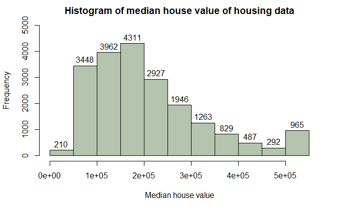

```r
hist(housing$median_house_value, xlab = "Median house value", main = "Histogram of median house value of housing data", col = "#B4C4AE", label = TRUE, ylim = c(0,5000))
```

- From the histogram it can be seen that median_house_value is positively skewed meaning most of the median_house_value have values less than its mean.

**ii. Boxplot of median_house_value:**

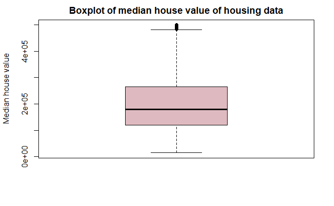

```r
boxplot(housing$median_house_value, ylab= "Median house value", main="Boxplot of median house value of housing data", col="#DEBAC0", label=TRUE)
```

- From the boxplot it can be seen that median_house_value is positively skewed as the length of the whiskers is more above the box compared to the length of the whisker below the box. Also, the median (horizontal line inside the box) is closer to line indicating Q1 than line indicating Q3. This means most of the median_house_value have values less than its mean.

**6. Analyze distribution of median_house_value using q-q plot:**

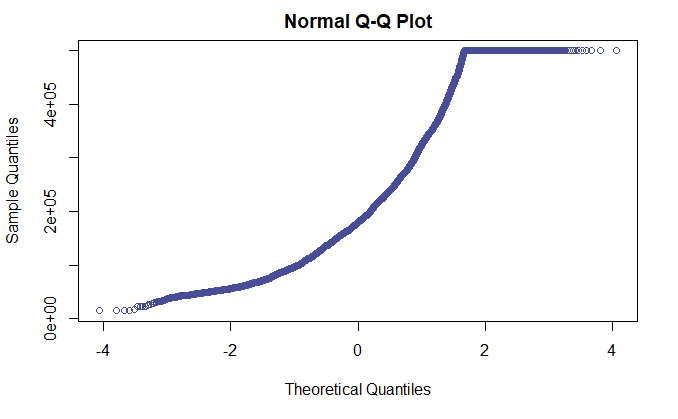

```r
qqnorm(housing$median_house_value, col = "#494C97")
```

- From the q-q plot it can be seen that median_house_value looks like curve and then a horizontal line. Therefore the median_house_value plot is not close to a straight line meaning its distribution is not close to normal. As it is mostly a curve it distribution is skewed.

**7. Ouliers of median_house_value:**

```r
x = housing$median_house_value
iqr = IQR(x)
q1 = summary(x)[[2]]
q3 = summary(x)[[5]]
left = q1 - 1.5 * iqr
right = q3 + 1.5 * iqr
outliers = x[x < left | x > right]
length(outliers)
```

```
[1] 1071
```

- There are 1071 outliers for median_house_value attribute.

**8. Analyze positive/negative linear correlation for numerical attributes with median_house_value:**

**i. Scatterplots:**

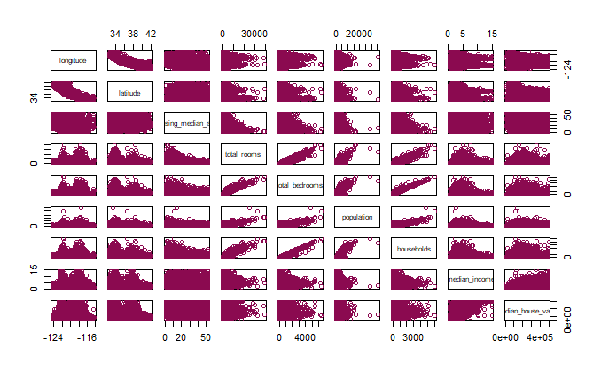

```r
housing_num = housing[,names(housing)[1:9]]
pairs(housing_num, col="deeppink4")
```

**ii. cor matrix:**

```r
cor(housing_num, use="pairwise.complete.obs")
```

```
                     longitude    latitude housing_median_age total_rooms
longitude           1.00000000 -0.92466443        -0.10819681  0.04456798
latitude           -0.92466443  1.00000000         0.01117267 -0.03609960
housing_median_age -0.10819681  0.01117267         1.00000000 -0.36126220
total_rooms         0.04456798 -0.03609960        -0.36126220  1.00000000
total_bedrooms      0.06960802 -0.06698283        -0.32045104  0.93037950
population          0.09977322 -0.10878475        -0.29624424  0.85712597
households          0.05531009 -0.07103543        -0.30291601  0.91848449
median_income      -0.01517587 -0.07980913        -0.11903399  0.19804965
median_house_value -0.04596662 -0.14416028         0.10562341  0.13415311
                   total_bedrooms   population  households median_income
longitude              0.06960802  0.099773223  0.05531009  -0.015175865
latitude              -0.06698283 -0.108784747 -0.07103543  -0.079809127
housing_median_age    -0.32045104 -0.296244240 -0.30291601  -0.119033990
total_rooms            0.93037950  0.857125973  0.91848449   0.198049645
total_bedrooms         1.00000000  0.877746743  0.97972827  -0.007722850
population             0.87774674  1.000000000  0.90722227   0.004834346
households             0.97972827  0.907222266  1.00000000   0.013033052
median_income         -0.00772285  0.004834346  0.01303305   1.000000000
median_house_value     0.04968618 -0.024649679  0.06584265   0.688075208
                   median_house_value
longitude                 -0.04596662
latitude                  -0.14416028
housing_median_age         0.10562341
total_rooms                0.13415311
total_bedrooms             0.04968618
population                -0.02464968
households                 0.06584265
median_income              0.68807521
median_house_value         1.00000000
```

- From the above scatter plots and correlation matrix we can say there is a positive linear correlation between median_income and median_house_value attributes. 0.688075208 is the value returned by cor matrix for correlation between median_income and median_house_value attributes.

**9. Analyze if there is statistically significant difference between the mean of median_house_value across different levels of ocean_proximity:**

**i. Using boxplot:**

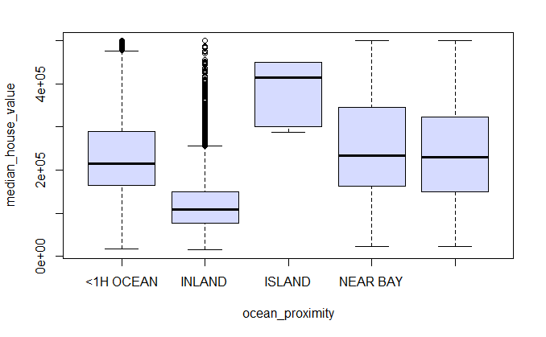

```r
attach(housing)
boxplot(median_house_value~ocean_proximity, col="#D6DBFF")
```

**ii. Using oneway.test:**

```r
oneway.test(median_house_value~ocean_proximity, data=housing)
```

```
    One-way analysis of means (not assuming equal variances)

data:  median_house_value and ocean_proximity
F = 2079.3, num df = 4.000, denom df = 31.919, p-value < 2.2e-16
```

- From the above boxplot and oneway.test we can conclude that there is significant difference between the mean of median_house_value across different levels of ocean_proximity as p-value returned using oneway.test is less than alpha (0.01)

**10. “Is_Inland” factor variable that takes the value “Yes” if the ocean_proximity is “Inland” and No” otherwise:**

```r
Is_Inland = factor(ifelse(ocean_proximity=="INLAND","YES","NO"))
Is_Inland
```

```
   [1] NO  NO  NO  NO  NO  NO  NO  NO  NO  NO  NO  NO  NO  NO  NO  NO  NO  NO
  [19] NO  NO  NO  NO  NO  NO  NO  NO  NO  NO  NO  NO  NO  NO  NO  NO  NO  NO
  [37] NO  NO  NO  NO  NO  NO  NO  NO  NO  NO  NO  NO  NO  NO  NO  NO  NO  NO
  [55] NO  NO  NO  NO  NO  NO  NO  NO  NO  NO  NO  NO  NO  NO  NO  NO  NO  NO
  [73] NO  NO  NO  NO  NO  NO  NO  NO  NO  NO  NO  NO  NO  NO  NO  NO  NO  NO
  [91] NO  NO  NO  NO  NO  NO  NO  NO  NO  NO  NO  NO  NO  NO  NO  NO  NO  NO
 [109] NO  NO  NO  NO  NO  NO  NO  NO  NO  NO  NO  NO  NO  NO  NO  NO  NO  NO
 [127] NO  NO  NO  NO  NO  NO  NO  NO  NO  NO  NO  NO  NO  NO  NO  NO  NO  NO
 [145] NO  NO  NO  NO  NO  NO  NO  NO  NO  NO  NO  NO  NO  NO  NO  NO  NO  NO
 [163] NO  NO  NO  NO  NO  NO  NO  NO  NO  NO  NO  NO  NO  NO  NO  NO  NO  NO
 [181] NO  NO  NO  NO  NO  NO  NO  NO  NO  NO  NO  NO  NO  NO  NO  NO  NO  NO
 [199] NO  NO  NO  NO  NO  NO  NO  NO  NO  NO  NO  NO  NO  NO  NO  NO  NO  NO
 [217] NO  NO  NO  NO  NO  NO  NO  NO  NO  NO  NO  NO  NO  NO  NO  NO  NO  NO
 [235] NO  NO  NO  NO  NO  NO  NO  NO  NO  NO  NO  NO  NO  NO  NO  NO  NO  NO
 [253] NO  NO  NO  NO  NO  NO  NO  NO  NO  NO  NO  NO  NO  NO  NO  NO  NO  NO
```

[output cut: 43 more lines]

**11.**

**i. Side by side box plot to visualize the relationship between “Is_Inland” and “median_house_value”:**

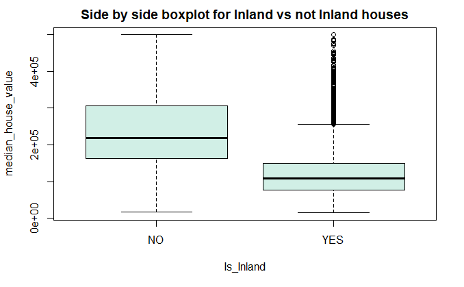

```r
boxplot(median_house_value~Is_Inland, col = "#D1EFE6", main="Side by side boxplot for Inland vs not Inland houses")
```

**ii. Statistical test to see if there is significant difference between the means of median_house_value for Inland vs not Inland houses:**

```r
t.test(median_house_value~Is_Inland, alternative="two.sided")
```

```
    Welch Two Sample t-test

data:  median_house_value by Is_Inland
t = 93.704, df = 18987, p-value < 2.2e-16
alternative hypothesis: true difference in means is not equal to 0
95 percent confidence interval:
 117687.3 122716.0
sample estimates:
 mean in group NO mean in group YES
         245007.0          124805.4
```

- From the above side by side boxplot and t.test we can conclude that there is significant difference between the means of median_house_value for Inland vs not Inland houses because p-value returned using t.test is less than alpha (0.01)